# Restaurant_Turnover_Prediction_ipynb_project

**Problem Statement:**

The first thing any visitor to India will take in — probably while staring out the window in awe as their aeroplane descends is the sheer size of this country. It is densely populated and patch-worked with distinct neighbourhoods, each with its own culinary identity. It would take several lifetimes to get to know all of the street stands, holes in the wall, neighbourhood favourites, and high-end destinations in this city. And for Indians dining out is and always will be a joyous occasion. Everyone has their own favourite restaurants in the city starting from the street food stall across the street to the 5-star restaurants in the heart of the city. Some are favourites because of the memory attached to it and some are favourites because of the fact that the place has a fantastic ambience. There are a lot of other factors as well which contribute to the likeness of the restaurants which in turn determines their popularity among the masses.

If you look at this from the business perspective for a restaurant, more popularity may mean more visits to the joint increasing the annual turnover of the restaurants. For any restaurant to survive and do well, the annual turnover of the restaurants has to be substantial.

This problem takes a shot at predicting the annual turnover of a set of restaurants across India based on a set of variables given in the data set. This includes the data related to the restaurant such as location, opening date, cuisine type, themes etc. This also includes data pooled from different sources such as social media popularity index, Zomato ratings, etc. Lastly, it also adds a different flavour to the problem by looking at the Customer survey data as well as ratings provided by mystery visitor data (audit done by a third party).

```python
# %%shell
# jupyter nbconvert --to html /content/Hackathon_Restaurant_Turnover_Prediction.ipynb
```

```python
# Make the Python code more structured automatically
#%load_ext nb_black

# Libraries to help with reading and manipulating data
import numpy as np
import pandas as pd

# Libraries to help with data visualization
import matplotlib.pyplot as plt
import seaborn as sns

sns.set_style("darkgrid")

# This is so I can see the entire dataframe when I print it
pd.set_option("display.max_columns", None)

# to split the data into train and test
from sklearn.model_selection import train_test_split

# to build linear regression_model
from sklearn.linear_model import LinearRegression

# to check model performance
from sklearn.metrics import mean_absolute_error, mean_squared_error, r2_score

# to build linear regression_model using statsmodels
import statsmodels.api as sm

# to check for homoscedasticity
import statsmodels.stats.api as sms
from statsmodels.compat import lzip

# to check for multicollinearity
from statsmodels.stats.outliers_influence import variance_inflation_factor
# to check for normality
import scipy.stats as stats

# To build model for prediction
from sklearn.tree import DecisionTreeClassifier
from sklearn import tree

# To tune different models
from sklearn.model_selection import GridSearchCV

import pandas as pd
import numpy as np
from sklearn.linear_model import RidgeCV

from sklearn.model_selection import train_test_split
from sklearn.metrics import mean_squared_error
```

```python
train = pd.read_csv("Train_dataset.csv")
train.head()
```

|  | Registration Number | Annual Turnover | Cuisine | City | Restaurant Location | Opening Day of Restaurant | Facebook Popularity Quotient | Endorsed By | Instagram Popularity Quotient | Fire Audit | Liquor License Obtained | Situated in a Multi Complex | Dedicated Parking | Open Sitting Available | Resturant Tier | Restaurant Type | Restaurant Theme | Restaurant Zomato Rating | Restaurant City Tier | Order Wait Time | Staff Responsivness | Value for Money | Hygiene Rating | Food Rating | Overall Restaurant Rating | Live Music Rating | Comedy Gigs Rating | Value Deals Rating | Live Sports Rating | … |
| --- | --- | --- | --- | --- | --- | --- | --- | --- | --- | --- | --- | --- | --- | --- | --- | --- | --- | --- | --- | --- | --- | --- | --- | --- | --- | --- | --- | --- | --- | --- |
| 0 | 60001 | 42000000 | indian,irish | Bangalore | Near Business Hub | 14/02/09 | 84.3 | Not Specific | 95.8 | 1 | 1 | 1 | 0 | 1 | 2.0 | Bar | Arabian | 3 | 0 | 2 | 5 | 5 | 5 | 7 | 10.0 | 4.0 | NaN | NaN | NaN | … |
| 1 | 60002 | 50000000 | indian,irish | Indore | Near Party Hub | 29/09/08 | 85.4 | Tier A Celebrity | 85.0 | 1 | 1 | 1 | 1 | 0 | 2.0 | Bar | Greek | 3 | 0 | 6 | 6 | 6 | 7 | 8 | 9.0 | NaN | 4.0 | NaN | NaN | … |
| 2 | 60003 | 32500000 | tibetan,italian | Chennai | Near Business Hub | 30/07/11 | 85.0 | Tier A Celebrity | 68.2 | 1 | 1 | 1 | 1 | 0 | 2.0 | Bar | 90's | 3 | 0 | 2 | 6 | 5 | 3 | 7 | 8.0 | 3.0 | NaN | NaN | NaN | … |
| 3 | 60004 | 110000000 | turkish,nigerian | Gurgaon | Near Party Hub | 30/11/08 | 85.6 | Tier A Celebrity | 83.6 | 0 | 1 | 1 | 1 | 1 | 1.0 | Bar | Arabian | 3 | 1 | 7 | 6 | 5 | 6 | 8 | 9.0 | 6.0 | NaN | NaN | NaN | … |
| 4 | 60005 | 20000000 | irish,belgian | Manesar | Near Party Hub | 22/02/10 | NaN | Tier A Celebrity | 76.8 | 1 | 1 | 1 | 1 | 1 | NaN | Bar | Greek | 3 | 0 | 10 | 5 | 6 | 4 | 8 | 6.0 | NaN | 2.0 | NaN | NaN | … |

```python
test = pd.read_csv("Test_dataset.csv")
test.head()
```

|  | Registration Number | Cuisine | City | Restaurant Location | Opening Day of Restaurant | Facebook Popularity Quotient | Endoresed By | Instagram Popularity Quotient | Fire Audit | Liquor License Obtained | Situated in a Multi Complex | Dedicated Parking | Open Sitting Available | Resturant Tier | Restaurant Type | Restaurant Theme | Restaurant Zomato Rating | Restaurant City Tier | Order Wait Time | Staff Responsivness | Value for Money | Hygiene Rating | Food Rating | Overall Restaurant Rating | Live Music Rating | Comedy Gigs Rating | Value Deals Rating | Live Sports Rating | Ambience | … |
| --- | --- | --- | --- | --- | --- | --- | --- | --- | --- | --- | --- | --- | --- | --- | --- | --- | --- | --- | --- | --- | --- | --- | --- | --- | --- | --- | --- | --- | --- | --- |
| 0 | 20001 | tibetan,italian | Bangalore | Near Business Hub | 13/07/10 | 78.00 | Tier A Celebrity | 69.00 | 1 | 1 | 1 | 1 | 0 | 2 | Bar | Greek | 3 | 0 | 10 | 5 | 3 | 5 | 8 | 6.0 | NaN | 2.0 | NaN | NaN | 5 | … |
| 1 | 20002 | tibetan,italian | Hyderabad | Near Party Hub | 05/09/11 | 89.17 | Not Specific | 96.00 | 1 | 1 | 1 | 1 | 1 | 2 | Bar | Nature | 4 | 0 | 10 | 4 | 5 | 6 | 8 | 9.0 | 3.0 | NaN | NaN | 6.0 | 7 | … |
| 2 | 20003 | algerian,belgian | Hyderabad | Near Party Hub | 12/04/11 | 84.00 | Not Specific | 86.00 | 1 | 1 | 1 | 0 | 1 | 2 | Bar | Greek | 2 | 0 | 6 | 5 | 5 | 6 | 9 | 6.0 | 3.0 | NaN | NaN | NaN | 9 | … |
| 3 | 20004 | tibetan,greek | -1 | Near Party Hub | 16/01/05 | 79.38 | Not Specific | 74.40 | 0 | 1 | 1 | 1 | 1 | 2 | Gastro Bar | 90's | 3 | 0 | 10 | 5 | 5 | 5 | 9 | 9.0 | 6.0 | NaN | NaN | NaN | 6 | … |
| 4 | 20005 | cuban,british | Pune | Near Party Hub | 10/11/08 | 84.67 | Not Specific | 86.46 | 1 | 1 | 1 | 0 | 0 | 1 | Bar | Mise En | 4 | 1 | 7 | 5 | 5 | 7 | 8 | NaN | NaN | NaN | NaN | NaN | 4 | … |

```python
#Rename Columns
train = train.rename(columns={"Resturant Tier": "Restaurant Tier"})
train = train.rename(columns={"Staff Responsivness": "Staff Responsiveness"})
train = train.rename(columns={"Comfortablility": "Comfortability"})
```

```python
#Rename Columns
test = test.rename(columns={"Endoresed By": "Endorsed By"})
test = test.rename(columns={"Resturant Tier": "Restaurant Tier"})
test = test.rename(columns={"Staff Responsivness": "Staff Responsiveness"})
test = test.rename(columns={"Comfortablility": "Comfortability"})
```

```python
train.shape,test.shape
```

```
((3493, 34), (500, 33))
```

```python
df=pd.concat([train,test])
df.head()
```

|  | Registration Number | Annual Turnover | Cuisine | City | Restaurant Location | Opening Day of Restaurant | Facebook Popularity Quotient | Endorsed By | Instagram Popularity Quotient | Fire Audit | Liquor License Obtained | Situated in a Multi Complex | Dedicated Parking | Open Sitting Available | Restaurant Tier | Restaurant Type | Restaurant Theme | Restaurant Zomato Rating | Restaurant City Tier | Order Wait Time | Staff Responsiveness | Value for Money | Hygiene Rating | Food Rating | Overall Restaurant Rating | Live Music Rating | Comedy Gigs Rating | Value Deals Rating | Live Sports Rating | … |
| --- | --- | --- | --- | --- | --- | --- | --- | --- | --- | --- | --- | --- | --- | --- | --- | --- | --- | --- | --- | --- | --- | --- | --- | --- | --- | --- | --- | --- | --- | --- |
| 0 | 60001 | 42000000.0 | indian,irish | Bangalore | Near Business Hub | 14/02/09 | 84.3 | Not Specific | 95.8 | 1 | 1 | 1 | 0 | 1 | 2.0 | Bar | Arabian | 3 | 0 | 2 | 5 | 5 | 5 | 7 | 10.0 | 4.0 | NaN | NaN | NaN | … |
| 1 | 60002 | 50000000.0 | indian,irish | Indore | Near Party Hub | 29/09/08 | 85.4 | Tier A Celebrity | 85.0 | 1 | 1 | 1 | 1 | 0 | 2.0 | Bar | Greek | 3 | 0 | 6 | 6 | 6 | 7 | 8 | 9.0 | NaN | 4.0 | NaN | NaN | … |
| 2 | 60003 | 32500000.0 | tibetan,italian | Chennai | Near Business Hub | 30/07/11 | 85.0 | Tier A Celebrity | 68.2 | 1 | 1 | 1 | 1 | 0 | 2.0 | Bar | 90's | 3 | 0 | 2 | 6 | 5 | 3 | 7 | 8.0 | 3.0 | NaN | NaN | NaN | … |
| 3 | 60004 | 110000000.0 | turkish,nigerian | Gurgaon | Near Party Hub | 30/11/08 | 85.6 | Tier A Celebrity | 83.6 | 0 | 1 | 1 | 1 | 1 | 1.0 | Bar | Arabian | 3 | 1 | 7 | 6 | 5 | 6 | 8 | 9.0 | 6.0 | NaN | NaN | NaN | … |
| 4 | 60005 | 20000000.0 | irish,belgian | Manesar | Near Party Hub | 22/02/10 | NaN | Tier A Celebrity | 76.8 | 1 | 1 | 1 | 1 | 1 | NaN | Bar | Greek | 3 | 0 | 10 | 5 | 6 | 4 | 8 | 6.0 | NaN | 2.0 | NaN | NaN | … |

```python
# Returns Statistical summary of the data for Numerical Datatype
df.describe(exclude=[object]).T
```

|  | count | mean | std | min | 25% | 50% | 75% | max |
| --- | --- | --- | --- | --- | --- | --- | --- | --- |
| Registration Number | 3993.0 | 5.655084e+04 | 1.376814e+04 | 20001.0 | 60499.00 | 61497.00 | 6.249500e+04 | 6.349300e+04 |
| Annual Turnover | 3493.0 | 3.072571e+07 | 2.165125e+07 | 3500000.0 | 18000000.00 | 30000000.00 | 3.700000e+07 | 4.000000e+08 |
| Facebook Popularity Quotient | 3894.0 | 7.788768e+01 | 9.861789e+00 | 43.0 | 71.66 | 79.00 | 8.566750e+01 | 9.776000e+01 |
| Instagram Popularity Quotient | 3937.0 | 7.444895e+01 | 1.099066e+01 | 40.0 | 66.00 | 74.33 | 8.260000e+01 | 9.870000e+01 |
| Fire Audit | 3993.0 | 7.918858e-01 | 4.060098e-01 | 0.0 | 1.00 | 1.00 | 1.000000e+00 | 1.000000e+00 |
| Liquor License Obtained | 3993.0 | 9.879790e-01 | 1.089931e-01 | 0.0 | 1.00 | 1.00 | 1.000000e+00 | 1.000000e+00 |
| Situated in a Multi Complex | 3993.0 | 8.056599e-01 | 3.957414e-01 | 0.0 | 1.00 | 1.00 | 1.000000e+00 | 1.000000e+00 |
| Dedicated Parking | 3993.0 | 8.026546e-01 | 3.980450e-01 | 0.0 | 1.00 | 1.00 | 1.000000e+00 | 1.000000e+00 |
| Open Sitting Available | 3993.0 | 8.006511e-01 | 3.995609e-01 | 0.0 | 1.00 | 1.00 | 1.000000e+00 | 1.000000e+00 |
| Restaurant Tier | 3944.0 | 1.927231e+00 | 2.597895e-01 | 1.0 | 2.00 | 2.00 | 2.000000e+00 | 2.000000e+00 |
| Restaurant Zomato Rating | 3993.0 | 2.697471e+00 | 7.860483e-01 | 0.0 | 2.00 | 3.00 | 3.000000e+00 | 5.000000e+00 |
| Restaurant City Tier | 3993.0 | 3.002755e-01 | 4.584351e-01 | 0.0 | 0.00 | 0.00 | 1.000000e+00 | 1.000000e+00 |
| Order Wait Time | 3993.0 | 5.516404e+00 | 2.861498e+00 | 1.0 | 3.00 | 6.00 | 8.000000e+00 | 1.000000e+01 |
| Staff Responsiveness | 3993.0 | 4.542950e+00 | 1.089309e+00 | 1.0 | 4.00 | 5.00 | 5.000000e+00 | 8.000000e+00 |
| Value for Money | 3993.0 | 4.524668e+00 | 9.102814e-01 | 1.0 | 4.00 | 5.00 | 5.000000e+00 | 7.000000e+00 |
| Hygiene Rating | 3993.0 | 4.658152e+00 | 1.252090e+00 | 1.0 | 4.00 | 5.00 | 5.000000e+00 | 9.000000e+00 |
| Food Rating | 3993.0 | 7.515903e+00 | 1.720532e+00 | 5.0 | 6.00 | 7.00 | 9.000000e+00 | 1.000000e+01 |
| Overall Restaurant Rating | 3747.0 | 8.478249e+00 | 1.289302e+00 | 6.0 | 7.00 | 9.00 | 1.000000e+01 | 1.000000e+01 |
| Live Music Rating | 3126.0 | 4.015355e+00 | 1.004830e+00 | 1.0 | 3.00 | 4.00 | 5.000000e+00 | 8.000000e+00 |
| Comedy Gigs Rating | 1140.0 | 2.942105e+00 | 8.790703e-01 | 1.0 | 2.00 | 3.00 | 3.000000e+00 | 6.000000e+00 |
| Value Deals Rating | 901.0 | 3.638180e+00 | 9.741359e-01 | 1.0 | 3.00 | 4.00 | 4.000000e+00 | 7.000000e+00 |
| Live Sports Rating | 234.0 | 3.602564e+00 | 8.983496e-01 | 2.0 | 3.00 | 4.00 | 4.000000e+00 | 6.000000e+00 |
| Ambience | 3968.0 | 6.416583e+00 | 2.046620e+00 | 0.0 | 5.00 | 7.00 | 8.000000e+00 | 1.000000e+01 |
| Lively | 3993.0 | 6.862760e+00 | 1.849605e+00 | 0.0 | 6.00 | 7.00 | 8.000000e+00 | 1.000000e+01 |
| Service | 3993.0 | 4.649136e+00 | 1.894872e+00 | 0.0 | 3.00 | 5.00 | 6.000000e+00 | 1.000000e+01 |
| Comfortability | 3993.0 | 3.360130e+00 | 2.017964e+00 | 0.0 | 2.00 | 3.00 | 5.000000e+00 | 1.000000e+01 |
| Privacy | 3993.0 | 6.265965e+00 | 1.899764e+00 | 0.0 | 5.00 | 6.00 | 8.000000e+00 | 1.000000e+01 |

```python
# Returns Statistical summary of the data for object Datatype
df.describe(exclude=[np.number]).T
```

|  | count | unique | top | freq |
| --- | --- | --- | --- | --- |
| Cuisine | 3993 | 20 | tibetan,greek | 801 |
| City | 3993 | 334 | Bangalore | 627 |
| Restaurant Location | 3993 | 2 | Near Party Hub | 3036 |
| Opening Day of Restaurant | 3993 | 1870 | 27/12/09 | 11 |
| Endorsed By | 3993 | 3 | Not Specific | 2260 |
| Restaurant Type | 3993 | 4 | Bar | 3695 |
| Restaurant Theme | 3993 | 34 | Arabian | 1592 |

```python
df.duplicated().sum()
```

```
0
```

No Duplicate values observed

```python
df.isnull().sum()
```

|  | 0 |
| --- | --- |
| Registration Number | 0 |
| Annual Turnover | 500 |
| Cuisine | 0 |
| City | 0 |
| Restaurant Location | 0 |
| Opening Day of Restaurant | 0 |
| Facebook Popularity Quotient | 99 |
| Endorsed By | 0 |
| Instagram Popularity Quotient | 56 |
| Fire Audit | 0 |
| Liquor License Obtained | 0 |
| Situated in a Multi Complex | 0 |
| Dedicated Parking | 0 |
| Open Sitting Available | 0 |
| Restaurant Tier | 49 |
| Restaurant Type | 0 |
| Restaurant Theme | 0 |
| Restaurant Zomato Rating | 0 |
| Restaurant City Tier | 0 |
| Order Wait Time | 0 |
| Staff Responsiveness | 0 |
| Value for Money | 0 |
| Hygiene Rating | 0 |
| Food Rating | 0 |
| Overall Restaurant Rating | 246 |
| Live Music Rating | 867 |
| Comedy Gigs Rating | 2853 |
| Value Deals Rating | 3092 |
| Live Sports Rating | 3759 |
| Ambience | 25 |
| Lively | 0 |
| Service | 0 |
| Comfortability | 0 |
| Privacy | 0 |

**dtype:** int64

```python
#Missing value analysis
null_train=pd.DataFrame()
null_train['Features']=df.isnull().sum().index
null_train['Null values']=df.isnull().sum().values
null_train['% Null values']=(df.isnull().sum().values / df.shape[0])*100
null_train.sort_values(by='% Null values',ascending=False)
```

|  | Features | Null values | % Null values |
| --- | --- | --- | --- |
| 28 | Live Sports Rating | 3759 | 94.139745 |
| 27 | Value Deals Rating | 3092 | 77.435512 |
| 26 | Comedy Gigs Rating | 2853 | 71.450038 |
| 25 | Live Music Rating | 867 | 21.712998 |
| 1 | Annual Turnover | 500 | 12.521913 |
| 24 | Overall Restaurant Rating | 246 | 6.160781 |
| 6 | Facebook Popularity Quotient | 99 | 2.479339 |
| 8 | Instagram Popularity Quotient | 56 | 1.402454 |
| 14 | Restaurant Tier | 49 | 1.227148 |
| 29 | Ambience | 25 | 0.626096 |
| 23 | Food Rating | 0 | 0.000000 |
| 21 | Value for Money | 0 | 0.000000 |
| 22 | Hygiene Rating | 0 | 0.000000 |
| 0 | Registration Number | 0 | 0.000000 |
| 19 | Order Wait Time | 0 | 0.000000 |
| 30 | Lively | 0 | 0.000000 |
| 31 | Service | 0 | 0.000000 |
| 32 | Comfortability | 0 | 0.000000 |
| 20 | Staff Responsiveness | 0 | 0.000000 |
| 17 | Restaurant Zomato Rating | 0 | 0.000000 |
| 18 | Restaurant City Tier | 0 | 0.000000 |
| 16 | Restaurant Theme | 0 | 0.000000 |
| 15 | Restaurant Type | 0 | 0.000000 |
| 13 | Open Sitting Available | 0 | 0.000000 |
| 12 | Dedicated Parking | 0 | 0.000000 |
| 11 | Situated in a Multi Complex | 0 | 0.000000 |
| 10 | Liquor License Obtained | 0 | 0.000000 |
| 9 | Fire Audit | 0 | 0.000000 |
| 7 | Endorsed By | 0 | 0.000000 |
| 5 | Opening Day of Restaurant | 0 | 0.000000 |
| 4 | Restaurant Location | 0 | 0.000000 |
| 3 | City | 0 | 0.000000 |
| 2 | Cuisine | 0 | 0.000000 |
| 33 | Privacy | 0 | 0.000000 |

```python
# We will drop the columns which are having more than 50% NULL Values
null_columns=null_train[null_train['% Null values']>=50]['Features']
df.drop(columns=null_columns,inplace=True)
np.array(null_columns)     ##Columns that are removed
```

```
array(['Comedy Gigs Rating', 'Value Deals Rating', 'Live Sports Rating'],
      dtype=object)
```

```python
#Missing value Treatment
numeric_cols_train = df.select_dtypes(include=np.number).columns.tolist()
df[numeric_cols_train] = df[numeric_cols_train].apply(lambda x: x.fillna(x.median()), axis=0)

category_cols_train = df.select_dtypes(include='object').columns.tolist()
df[category_cols_train] = df[category_cols_train].apply(lambda x: x.fillna(x.value_counts().index[0]), axis=0)
```

```python
df['Opening Day of Restaurant']=df['Opening Day of Restaurant'].str.slice(-4)
yr=df.groupby(['Opening Day of Restaurant'])[['Annual Turnover']].mean().sort_values('Annual Turnover')
yr
```

| Opening Day of Restaurant | Annual Turnover |
| --- | --- |
| 5/00 | 11000000.0 |
| 0/96 | 12000000.0 |
| 8/02 | 12000000.0 |
| 0/04 | 17000000.0 |
| 3/13 | 17000000.0 |
| ... | ... |
| 2/02 | 45000000.0 |
| 0/06 | 55650000.0 |
| 7/03 | 68000000.0 |
| 9/06 | 93800000.0 |
| 9/03 | 145750000.0 |

114 rows × 1 columns

```python
d={}
c=1
for i in yr.index:
    d[i]=c
    c=c+1
print(d)
```

```
{'5/00': 1, '0/96': 2, '8/02': 3, '0/04': 4, '3/13': 5, '9/13': 6, '6/05': 7, '7/04': 8, '1/02': 9, '4/12': 10, '1/14': 11, '1/03': 12, '6/12': 13, '5/12': 14, '2/13': 15, '2/12': 16, '2/11': 17, '7/12': 18, '1/13': 19, '1/11': 20, '1/12': 21, '6/06': 22, '9/11': 23, '6/11': 24, '0/11': 25, '6/13': …
```

```python
df['Opening Day of Restaurant']=df['Opening Day of Restaurant'].map(d)
```

```python
tmp=df.groupby(['Cuisine'])[['Annual Turnover']].mean().sort_values('Annual Turnover')
tmp
```

| Cuisine | Annual Turnover |
| --- | --- |
| irish,belgian | 2.360000e+07 |
| chinese,salvadorian | 2.573118e+07 |
| welsh,thai | 2.658189e+07 |
| cuban,british | 2.671875e+07 |
| turkish,sapnish | 2.692188e+07 |
| swedish,greek | 2.742157e+07 |
| nigerian,cajun | 2.742857e+07 |
| peruvian,cuban | 2.815299e+07 |
| algerian,korean | 2.925000e+07 |
| algerian,belgian | 2.928977e+07 |
| algerian,algerian | 3.044444e+07 |
| british,belgian | 3.051163e+07 |
| british,japanese | 3.096984e+07 |
| tibetan,italian | 3.119614e+07 |
| indian,irish | 3.185377e+07 |
| polish,jewish | 3.255039e+07 |
| tibetan,greek | 3.353308e+07 |
| japanese,thai | 3.402018e+07 |
| turkish,nigerian | 3.442886e+07 |
| hawaiian,latvian | 3.809091e+07 |

```python
d={}
c=1
for i in tmp.index:
    d[i]=c
    c=c+1
print(d)
```

```
{'irish,belgian': 1, 'chinese,salvadorian': 2, 'welsh,thai': 3, 'cuban,british': 4, 'turkish,sapnish': 5, 'swedish,greek': 6, 'nigerian,cajun': 7, 'peruvian,cuban': 8, 'algerian,korean': 9, 'algerian,belgian': 10, 'algerian,algerian': 11, 'british,belgian': 12, 'british,japanese': 13, 'tibetan,itali…
```

```python
df['Cuisine']=df['Cuisine'].map(d)
```

```python
temp=df.groupby(['Restaurant Theme'])[['Annual Turnover']].mean().sort_values('Annual Turnover')
temp
```

| Restaurant Theme | Annual Turnover |
| --- | --- |
| Spoon | 1.000000e+07 |
| Grand | 1.000000e+07 |
| Umami | 1.483333e+07 |
| Cinnamon | 2.000000e+07 |
| Resca | 2.100000e+07 |
| Ambiance | 2.225000e+07 |
| TheGem | 2.458333e+07 |
| Picante | 2.550000e+07 |
| Marco | 2.560000e+07 |
| Belise | 2.673333e+07 |
| Moonrise | 2.826923e+07 |
| Parsi | 2.871901e+07 |
| Delicio | 2.877778e+07 |
| Chinese | 2.902439e+07 |
| Greek | 2.958856e+07 |
| Benedicta | 3.037500e+07 |
| Italica | 3.050000e+07 |
| 90's | 3.070106e+07 |
| Mise En | 3.111111e+07 |
| Arabian | 3.139824e+07 |
| Nature | 3.143731e+07 |
| Flavors | 3.200000e+07 |
| Petit | 3.210000e+07 |
| Bakery | 3.350000e+07 |
| Bettaso | 3.375000e+07 |
| Carbone | 3.383333e+07 |
| Molino | 3.493103e+07 |
| Sage | 3.600000e+07 |
| Cafepro | 3.700000e+07 |
| Downtown | 3.845000e+07 |
| Savory | 3.875000e+07 |
| English | 3.990000e+07 |
| Piquant | 4.600000e+07 |
| LaCuisine | 7.000000e+07 |

```python
d={}
c=1
for i in temp.index:
    d[i]=c
    c=c+1
print(d)
```

```
{'Spoon': 1, 'Grand': 2, 'Umami': 3, 'Cinnamon': 4, 'Resca': 5, 'Ambiance': 6, 'TheGem': 7, 'Picante': 8, 'Marco': 9, 'Belise': 10, 'Moonrise': 11, 'Parsi': 12, 'Delicio': 13, 'Chinese': 14, 'Greek': 15, 'Benedicta': 16, 'Italica': 17, "90's": 18, 'Mise En': 19, 'Arabian': 20, 'Nature': 21, 'Flavors…
```

```python
df['Restaurant Theme']=df['Restaurant Theme'].map(d)
```

```python
df.info()
```

```
<class 'pandas.core.frame.DataFrame'>
Index: 3993 entries, 0 to 499
Data columns (total 31 columns):
 #   Column                         Non-Null Count  Dtype
---  ------                         --------------  -----
 0   Registration Number            3993 non-null   int64
 1   Annual Turnover                3993 non-null   float64
 2   Cuisine                        3993 non-null   int64
 3   City                           3993 non-null   object
 4   Restaurant Location            3993 non-null   object
 5   Opening Day of Restaurant      3993 non-null   int64
 6   Facebook Popularity Quotient   3993 non-null   float64
 7   Endorsed By                    3993 non-null   object
 8   Instagram Popularity Quotient  3993 non-null   float64
 9   Fire Audit                     3993 non-null   int64
```

[output cut: 23 more lines]

```python
# Normalize the variables and compute the average normalized value for each row
df['Order Wait Time'] = (df['Order Wait Time'] - 1) / 9
df['Staff Responsiveness'] = (df['Staff Responsiveness'] - 1) / 7
df['Value for Money'] = (df['Value for Money'] - 1) / 6
# Normalize the variables and compute the average normalized value for each row
df['Hygiene Rating'] = (df['Hygiene Rating'] - 1) / 9
df['Food Rating'] = (df['Food Rating'] - 1) / 9
# Normalize the variables and compute the average normalized value for each row
df['Ambience'] = (df['Ambience'] - 0) / 9
df['Lively'] = (df['Lively'] - 1) / 9
df['Service'] = (df['Service'] - 0) / 19
df['Comfortability'] = (df['Comfortability'] - 0) / 9
df['Privacy'] = (df['Privacy'] - 0) / 9
df['Overall Restaurant Rating']= (df['Overall Restaurant Rating'] - 1) / 9
df['Lively and Privacy']=(df['Lively']+df['Privacy'])/2
df = df.drop(['Lively', 'Privacy'], axis=1)
```

```python
# Normalize Facebook Popularity Quotient and Instagram Popularity Quotient
df['Facebook Popularity Quotient'] = (df['Facebook Popularity Quotient'] - df['Facebook Popularity Quotient'].min()) / (df['Facebook Popularity Quotient'].max() - df['Facebook Popularity Quotient'].min())
df['Instagram Popularity Quotient'] = (df['Instagram Popularity Quotient'] - df['Instagram Popularity Quotient'].min()) / (df['Instagram Popularity Quotient'].max() - df['Instagram Popularity Quotient'].min())

# Combine normalized Facebook Popularity Quotient and Instagram Popularity Quotient into one variable
df['Media Popularity'] = (df['Facebook Popularity Quotient'] + df['Instagram Popularity Quotient']) / 2

# Drop the original Facebook Popularity Quotient and Instagram Popularity Quotient columns
df = df.drop(['Facebook Popularity Quotient', 'Instagram Popularity Quotient'], axis=1)
```

```python
df.info()
```

```
<class 'pandas.core.frame.DataFrame'>
Index: 3993 entries, 0 to 499
Data columns (total 29 columns):
 #   Column                       Non-Null Count  Dtype
---  ------                       --------------  -----
 0   Registration Number          3993 non-null   int64
 1   Annual Turnover              3993 non-null   float64
 2   Cuisine                      3993 non-null   int64
 3   City                         3993 non-null   object
 4   Restaurant Location          3993 non-null   object
 5   Opening Day of Restaurant    3993 non-null   int64
 6   Endorsed By                  3993 non-null   object
 7   Fire Audit                   3993 non-null   int64
 8   Liquor License Obtained      3993 non-null   int64
 9   Situated in a Multi Complex  3993 non-null   int64
```

[output cut: 21 more lines]

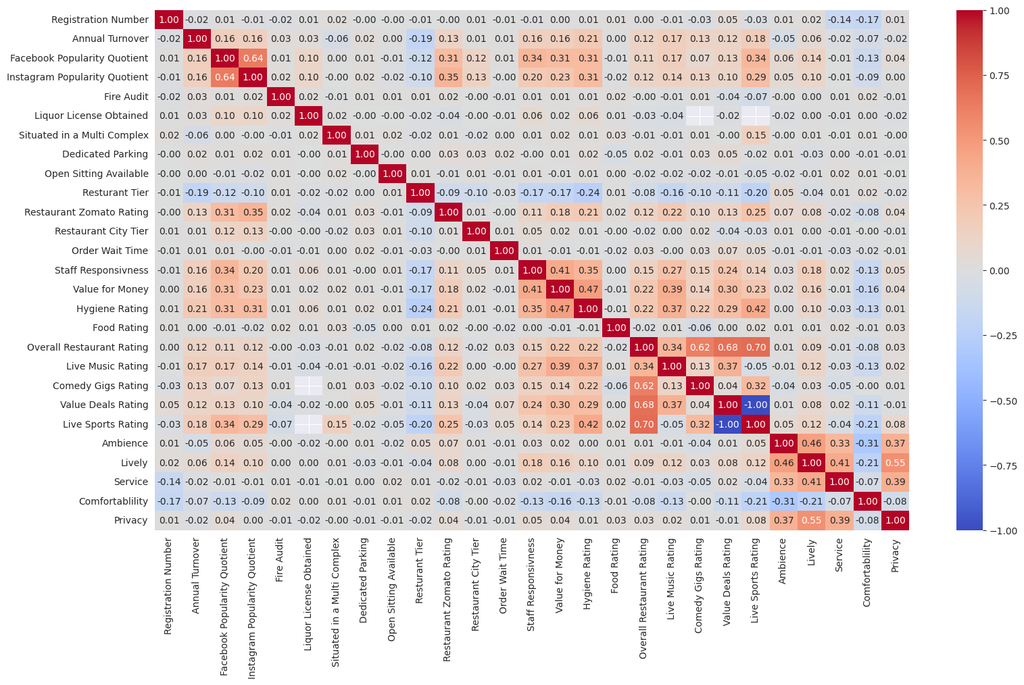

```python
# Make the Python code more structured automatically
#%load_ext nb_black

# Libraries to help with reading and manipulating data
import numpy as np
import pandas as pd

# Libraries to help with data visualization
import matplotlib.pyplot as plt
import seaborn as sns

sns.set_style("darkgrid")

# This is so I can see the entire dataframe when I print it
pd.set_option("display.max_columns", None)

# to split the data into train and test
from sklearn.model_selection import train_test_split

# to build linear regression_model
from sklearn.linear_model import LinearRegression

# to check model performance
from sklearn.metrics import mean_absolute_error, mean_squared_error, r2_score

# to build linear regression_model using statsmodels
import statsmodels.api as sm

# to check for homoscedasticity
import statsmodels.stats.api as sms
from statsmodels.compat import lzip

# to check for multicollinearity
from statsmodels.stats.outliers_influence import variance_inflation_factor
# to check for normality
import scipy.stats as stats

# To build model for prediction
from sklearn.tree import DecisionTreeClassifier
from sklearn import tree

# To tune different models
from sklearn.model_selection import GridSearchCV

import pandas as pd
import numpy as np
from sklearn.linear_model import RidgeCV

from sklearn.model_selection import train_test_split
from sklearn.metrics import mean_squared_error
# Read the training and test data into pandas DataFrames
# Make sure the file paths are correct
train = pd.read_csv("Train_dataset.csv")
test = pd.read_csv("Test_dataset.csv")

# Rest of your code below...

import pandas as pd
import numpy as np
import matplotlib.pyplot as plt
import seaborn as sns

# ... (Your existing code) ...

# Assuming 'train' and 'test' DataFrames are defined as before:
df = pd.concat([train, test])

# ... (Your data processing code) ...

plt.figure(figsize=(18, 10))
sns.heatmap(df.corr(numeric_only=True), annot=True, fmt='0.2f', cmap='coolwarm');
```

```python
Categorical_columns=["Restaurant Location","Endorsed By","Restaurant Type"]
df = pd.get_dummies(df, columns=Categorical_columns,drop_first=True)
```

```python
# Outlier Treament Function


def treat_outliers(df, col):
    """
    Treats outliers in a variable

    df: dataframe
    col: dataframe column
    """
    Q1 = df[col].quantile(0.25)  # 25th quantile
    Q3 = df[col].quantile(0.75)  # 75th quantile
    IQR = Q3 - Q1
    Lower_Whisker = Q1 - 1.5 * IQR
    Upper_Whisker = Q3 + 1.5 * IQR

    # all the values smaller than Lower_Whisker will be assigned the value of Lower_Whisker
    # all the values greater than Upper_Whisker will be assigned the value of Upper_Whisker
    df[col] = np.clip(df[col], Lower_Whisker, Upper_Whisker)

    return df


def treat_outliers_all(df, col_list):
    """
    Treat outliers in a list of variables

    df: dataframe
    col_list: list of dataframe columns
    """
    for c in col_list:
        df = treat_outliers(df, c)

    return df
```

```python
binomial_cols=["Fire Audit","Liquor License Obtained","Situated in a Multi Complex","Dedicated Parking",
"Open Sitting Available","Restaurant Tier",'Restaurant City Tier']
```

```python
#Outlier Treatment
numerical_cols = [col for col in train.select_dtypes(include=np.number).columns.tolist() if col not in binomial_cols]
print(numerical_cols)
data = treat_outliers_all(train, numerical_cols)
```

```
['Registration Number', 'Annual Turnover', 'Facebook Popularity Quotient', 'Instagram Popularity Quotient', 'Restaurant Zomato Rating', 'Order Wait Time', 'Staff Responsiveness', 'Value for Money', 'Hygiene Rating', 'Food Rating', 'Overall Restaurant Rating', 'Live Music Rating', 'Comedy Gigs Rating…
```

```python
#drop city column
df=df.drop('City', axis=1)
```

```python
df.info()
```

```
<class 'pandas.core.frame.DataFrame'>
Index: 3993 entries, 0 to 499
Data columns (total 31 columns):
 #   Column                                    Non-Null Count  Dtype
---  ------                                    --------------  -----
 0   Registration Number                       3993 non-null   int64
 1   Annual Turnover                           3993 non-null   float64
 2   Cuisine                                   3993 non-null   int64
 3   Opening Day of Restaurant                 3993 non-null   int64
 4   Fire Audit                                3993 non-null   int64
 5   Liquor License Obtained                   3993 non-null   int64
 6   Situated in a Multi Complex               3993 non-null   int64
 7   Dedicated Parking                         3993 non-null   int64
 8   Open Sitting Available                    3993 non-null   int64
 9   Restaurant Tier                           3993 non-null   float64
```

[output cut: 23 more lines]

**Data Modelling**

```python
X = df.drop(["Annual Turnover","Endorsed By_Not Specific"], axis=1)
y = df["Annual Turnover"]
```

```python
X.shape,y.shape
```

```
((3993, 29), (3993,))
```

```python
x_train=sm.add_constant(X.iloc[0:3493,:],has_constant='add')
```

```python
x_test=sm.add_constant(X.iloc[3493:,:],has_constant='add')
```

```python
y_train=y.iloc[0:3493]
```

```python
# initial list of columns
predictors = x_train.copy()
cols = predictors.columns.tolist()
cols.remove('const')

# Convert all columns in x_train_aux to numeric
# Non-numeric values will be coerced to NaN, and NaN values will be filled with 0
# This loop iterates through columns with 'object' dtype and attempts conversion
for col in predictors.select_dtypes(include=['object']).columns:
    predictors[col] = pd.to_numeric(predictors[col], errors='coerce').fillna(0)
    # Update the corresponding column in x_train_aux as well
    x_train_aux[col] = predictors[col] # This line updates the relevant columns in x_train_aux

# setting an initial max p-value
max_p_value = 1

while len(cols) > 0:
    # defining the train set
    x_train_aux = predictors[cols]

    # fitting the model
    # Replace infinite values with a large but finite number before fitting the model
    x_train_aux = x_train_aux.replace([np.inf, -np.inf], np.nan).fillna(0)
    model = sm.OLS(y_train, x_train_aux).fit()

    # getting the p-values and the maximum p-value
    p_values = model.pvalues
    max_p_value = max(p_values)

    # name of the variable with maximum p-value
    feature_with_p_max = p_values.idxmax()

    if max_p_value > 0.05:
        #print("The columns with P Value > 0.05", feature_with_p_max)
        cols.remove(feature_with_p_max)
    else:
        break

selected_features = cols
print(selected_features)
```

[output not shown]

```python
x_train.shape,x_test.shape,y_train.shape
```

```
((3493, 30), (500, 30), (3493,))
```

```python
#Change the datatype to numeric in x_train if its not numeric.
# Iterate through all columns of the DataFrame
for column in x_train.columns:
    # Check if the column's data type is not numeric
    if not pd.api.types.is_numeric_dtype(x_train[column]):
        # Convert the column's data type to numeric (float64) and replace errors with NaN
        x_train[column] = pd.to_numeric(x_train[column], errors='coerce')

# Handle missing values (NaN) after conversion
# Fill NaN values with a suitable replacement (e.g., median, mean, or a specific value)
x_train = x_train.fillna(x_train.median())  # Or use a different method to handle NaN values
```

```python
#Change the datatype to numeric in x_train if its not numeric.
# Iterate through all columns of the DataFrame
for column in x_train.columns:
    # Check if the column's data type is not numeric
    if not pd.api.types.is_numeric_dtype(x_train[column]):
        # Convert the column's data type to numeric (float64) and replace errors with NaN
        x_train[column] = pd.to_numeric(x_train[column], errors='coerce')

# Handle missing values (NaN) after conversion
# Fill NaN values with a suitable replacement (e.g., median, mean, or a specific value)
x_train = x_train.fillna(x_train.median())  # Or use a different method to handle NaN values

# Explicitly convert all columns to numeric using astype
# This ensures all columns have a numeric dtype, preventing issues with numpy functions
for col in x_train.columns:
    x_train[col] = x_train[col].astype(float) #Change to float

# Now calculate VIF
vif = calc_vif(x_train)
print(vif)
```

```
                                    variable          VIF
0                                      const  4156.064155
1                        Registration Number     1.005568
2                                    Cuisine     1.027906
3                  Opening Day of Restaurant     1.080234
4                                 Fire Audit     1.009054
5                    Liquor License Obtained     1.231886
6                Situated in a Multi Complex     1.005884
7                          Dedicated Parking     1.010265
8                     Open Sitting Available     1.005418
9                            Restaurant Tier     1.136980
10                          Restaurant Theme     1.085068
11                  Restaurant Zomato Rating     1.263400
12                      Restaurant City Tier     1.056369
13                           Order Wait Time     1.008106
```

[output cut: 16 more lines]

```python
import pandas as pd
import numpy as np
import statsmodels.api as sm
# to compute VIF
from statsmodels.stats.outliers_influence import variance_inflation_factor

# Calculate the VIF values for each predictor
def calc_vif(X):
    vif = pd.DataFrame()
    vif['variable'] = X.columns
    vif['VIF'] = [ variance_inflation_factor(X.values, i) for i in range(X.shape[1])]
    return vif

vif = calc_vif(x_train)
print(vif)
```

```
                                    variable          VIF
0                                      const  4156.064155
1                        Registration Number     1.005568
2                                    Cuisine     1.027906
3                  Opening Day of Restaurant     1.080234
4                                 Fire Audit     1.009054
5                    Liquor License Obtained     1.231886
6                Situated in a Multi Complex     1.005884
7                          Dedicated Parking     1.010265
8                     Open Sitting Available     1.005418
9                            Restaurant Tier     1.136980
10                          Restaurant Theme     1.085068
11                  Restaurant Zomato Rating     1.263400
12                      Restaurant City Tier     1.056369
13                           Order Wait Time     1.008106
```

[output cut: 16 more lines]

```python
#Change the datatype to numeric in x_train if its not numeric.
# Iterate through all columns of the DataFrame
for column in x_train.columns:
    # Check if the column's data type is not numeric
    if not pd.api.types.is_numeric_dtype(x_train[column]):
        # Convert the column's data type to numeric (float64) and replace errors with NaN
        x_train[column] = pd.to_numeric(x_train[column], errors='coerce')

# Handle missing values (NaN) after conversion
# Fill NaN values with a suitable replacement (e.g., median, mean, or a specific value)
x_train = x_train.fillna(x_train.median())  # Or use a different method to handle NaN values

# Convert all columns to numeric using to_numeric with errors='coerce'
# This ensures that any non-numeric values are converted to NaN
for col in x_train.select_dtypes(include=['object']).columns:
    x_train[col] = pd.to_numeric(x_train[col], errors='coerce')

# Fill NaN values with 0, you can also use mean or median
x_train = x_train.fillna(0)
```

```python
# Identify the predictors with high VIF values
high_vif_vars = vif[vif['VIF'] > 5]['variable'].values
print(high_vif_vars)
```

```
['const']
```

```python
# function to compute adjusted R-squared
def adj_r2_score(predictors, targets, predictions):
    r2 = r2_score(targets, predictions)
    n = predictors.shape[0]
    k = predictors.shape[1]
    return 1 - ((1 - r2) * (n - 1) / (n - k - 1))


# function to compute MAPE
def mape_score(targets, predictions):
    return np.mean(np.abs(targets - predictions) / targets) * 100


# function to compute different metrics to check performance of a regression model
def model_performance_regression(model, predictors, target):
    """
    Function to compute different metrics to check regression model performance

    model: regressor
    predictors: independent variables
    target: dependent variable
    """

    # predicting using the independent variables
    pred = model.predict(predictors)

    r2 = r2_score(target, pred)  # to compute R-squared
    adjr2 = adj_r2_score(predictors, target, pred)  # to compute adjusted R-squared
    rmse = np.sqrt(mean_squared_error(target, pred))  # to compute RMSE
    mae = mean_absolute_error(target, pred)  # to compute MAE
    mape = mape_score(target, pred)  # to compute MAPE

    # creating a dataframe of metrics
    df_perf = pd.DataFrame(
          {
            "RMSE": rmse,
            "MAE": mae,
            "R-squared": r2,
            "Adj. R-squared": adjr2,
            "MAPE": mape,
        },
        index=[0],
    )

    return df_perf
```

```python
# Assuming 'X' is your DataFrame with categorical columns
categorical_cols = ["Restaurant Location", "Endorsed By", "Restaurant Type", "Cuisine", "Restaurant Theme"]  # Add other categorical columns

# Ensure columns exist in DataFrame and have correct names before one-hot encoding
categorical_cols = [col for col in categorical_cols if col in X.columns]

# Perform one-hot encoding only on the columns that exist
X = pd.get_dummies(X, columns=categorical_cols, drop_first=True)  # Perform one-hot encoding

# Ensure all columns are numeric after one-hot encoding
for col in X.columns:
    if X[col].dtype == 'object':  # Check if column is of object type
        X[col] = pd.to_numeric(X[col], errors='coerce').fillna(0)  # Convert to numeric and fill NaN with 0

# Split data after one-hot encoding and ensuring numeric types
X_train, X_test, y_train, y_test = train_test_split(X, y, test_size=0.2, random_state=42)

# Drop rows with NaN values in the target variable (y_train)
X_train = X_train[y_train.notna()]  # Keep rows where y_train is not NaN
y_train = y_train.dropna()  # Drop NaN values from y_train


# Model training
rf = RandomForestRegressor(random_state=42)
rf.fit(X_train, y_train)
```

```
RandomForestRegressor(random_state=42)
```

```python
# Assuming 'X' is your DataFrame with categorical columns
categorical_cols = ["Restaurant Location", "Endorsed By", "Restaurant Type", "Cuisine", "Restaurant Theme"]  # Add other categorical columns

# Ensure columns exist in DataFrame and have correct names before one-hot encoding
categorical_cols = [col for col in categorical_cols if col in X.columns]

# Perform one-hot encoding only on the columns that exist
X = pd.get_dummies(X, columns=categorical_cols, drop_first=True)  # Perform one-hot encoding

# Ensure all columns are numeric after one-hot encoding
# Assuming 'X' is your DataFrame with categorical columns
categorical_cols = ["Restaurant Location", "Endorsed By", "Restaurant Type", "Cuisine", "Restaurant Theme"]  # Add other categorical columns

# Ensure columns exist in DataFrame and have correct names before one-hot encoding
categorical_cols = [col for col in categorical_cols if col in X.columns]

# Perform one-hot encoding only on the columns that exist
X = pd.get_dummies(X, columns=categorical_cols, drop_first=True)  # Perform one-hot encoding

# Ensure all columns are numeric after one-hot encoding
for col in X.columns:
    if X[col].dtype == 'object':  # Check if column is of object type
        X[col] = pd.to_numeric(X[col], errors='coerce')
```

```python
# Assuming 'X' is your DataFrame with categorical columns
categorical_cols = ["Restaurant Location", "Endorsed By", "Restaurant Type", "Cuisine", "Restaurant Theme"]  # Add other categorical columns

# Ensure columns exist in DataFrame and have correct names before one-hot encoding
categorical_cols = [col for col in categorical_cols if col in X.columns]

# Perform one-hot encoding only on the columns that exist
X = pd.get_dummies(X, columns=categorical_cols, drop_first=True)  # Perform one-hot encoding

# Ensure all columns are numeric after one-hot encoding
for col in X.columns:
    if X[col].dtype == 'object':  # Check if column is of object type
        X[col] = pd.to_numeric(X[col], errors='coerce').fillna(0)  # Convert to numeric and fill NaN with 0

# Split data after one-hot encoding and ensuring numeric types
X_train, X_test, y_train, y_test = train_test_split(X, y, test_size=0.2, random_state=42)

# Drop rows with NaN values in the target variable (y_train)
X_train = X_train[y_train.notna()]  # Keep rows where y_train is not NaN
y_train = y_train.dropna()  # Drop NaN values from y_train

# Drop rows with NaN values in the target variable (y_test)
X_test = X_test[y_test.notna()]  # Keep rows where y_test is not NaN
y_test = y_test.dropna()  # Drop NaN values from y_test


# Model training
rf = RandomForestRegressor(random_state=42)
rf.fit(X_train, y_train)

#Make prediction
y_pred = rf.predict(X_test)

# Evaluate RMSE
rmse = np.sqrt(mean_squared_error(y_test, y_pred))
print(f"RMSE: {rmse}")
```

```
RMSE: 25083909.135922767
```

```python
x_train.shape,x_test.shape,y_train.shape
```

[output not shown]

```python
olsmodel = sm.OLS(y_train,x_train).fit()
print(olsmodel.summary())
```

[output not shown]

```python
# initial list of columns
predictors = x_train.copy()
cols = predictors.columns.tolist()
cols.remove('const')
# setting an initial max p-value
max_p_value = 1

while len(cols) > 0:
    # defining the train set
    x_train_aux = predictors[cols]

    # fitting the model
    model = sm.OLS(y_train, x_train_aux).fit()

    # getting the p-values and the maximum p-value
    p_values = model.pvalues
    max_p_value = max(p_values)

    # name of the variable with maximum p-value
    feature_with_p_max = p_values.idxmax()

    if max_p_value > 0.05:
        #print("The columns with P Value > 0.05", feature_with_p_max)
        cols.remove(feature_with_p_max)
    else:
        break

selected_features = cols
print(selected_features)
```

```
['Cuisine', 'Opening Day of Restaurant', 'Situated in a Multi Complex', 'Restaurant Tier', 'Restaurant Theme', 'Restaurant Zomato Rating', 'Staff Responsiveness', 'Hygiene Rating', 'Live Music Rating', 'Ambience', 'Comfortability', 'Media Popularity', 'Restaurant Location_Near Party Hub']
```

```python
x_train = x_train[selected_features]
x_test = x_test[selected_features]
```

**OLS Model**

```python
olsmodel_final = sm.OLS(y_train,x_train).fit()
print(olsmodel_final.summary())
```

```
                                 OLS Regression Results
=======================================================================================
Dep. Variable:        Annual Turnover   R-squared (uncentered):                   0.723
Model:                            OLS   Adj. R-squared (uncentered):              0.722
Method:                 Least Squares   F-statistic:                              698.3
Date:                Fri, 17 Jan 2025   Prob (F-statistic):                        0.00
Time:                        13:18:57   Log-Likelihood:                         -63640.
No. Observations:                3493   AIC:                                  1.273e+05
Df Residuals:                    3480   BIC:                                  1.274e+05
Df Model:                          13
Covariance Type:            nonrobust
======================================================================================================
                                         coef    std err          t      P>|t|      [0.025      0.975]
------------------------------------------------------------------------------------------------------
Cuisine                             4.737e+05   5.79e+04      8.181      0.000     3.6e+05    5.87e+05
Opening Day of Restaurant           1.861e+05   1.27e+04     14.668      0.000    1.61e+05    2.11e+05
Situated in a Multi Complex        -3.008e+06    8.4e+05     -3.582      0.000   -4.65e+06   -1.36e+06
Restaurant Tier                    -8.127e+06      1e+06     -8.111      0.000   -1.01e+07   -6.16e+06
Restaurant Theme                    4.896e+05   9.86e+04      4.967      0.000    2.96e+05    6.83e+05
Restaurant Zomato Rating            1.533e+06   4.64e+05      3.301      0.001    6.23e+05    2.44e+06
Staff Responsiveness                7.146e+06   2.35e+06      3.039      0.002    2.54e+06    1.18e+07
Hygiene Rating                      1.289e+07   2.82e+06      4.563      0.000    7.35e+06    1.84e+07
Live Music Rating                   1.152e+06   4.08e+05      2.820      0.005    3.51e+05    1.95e+06
Ambience                           -4.887e+06   1.52e+06     -3.222      0.001   -7.86e+06   -1.91e+06
Comfortability                     -3.808e+06   1.57e+06     -2.428      0.015   -6.88e+06   -7.32e+05
Media Popularity                    1.737e+07   2.36e+06      7.348      0.000    1.27e+07     2.2e+07
Restaurant Location_Near Party Hub  1.853e+06   7.99e+05      2.318      0.021    2.85e+05    3.42e+06
==============================================================================
Omnibus:                     4715.845   Durbin-Watson:                   2.011
Prob(Omnibus):                  0.000   Jarque-Bera (JB):          1515912.798
Skew:                           7.503   Prob(JB):                         0.00
Kurtosis:                     103.948   Cond. No.                         555.
==============================================================================

Notes:
[1] R² is computed without centering (uncentered) since the model does not contain a constant.
[2] Standard Errors assume that the covariance matrix of the errors is correctly specified.
```

```python
# Make predictions on the test set using the trained model
y_test_pred = olsmodel_final.predict(x_test)

# Create a DataFrame with the Registration Number and predicted Annual Turnover values
results = pd.DataFrame({"Registration Number": test["Registration Number"], "Annual Turnover": y_test_pred})

# Convert the Annual Turnover column to integers
results["Annual Turnover"] = results["Annual Turnover"].astype(int)

# Set the Registration Number column as the index
results.set_index("Registration Number", inplace=True)

# Export the results as a CSV file
results.to_csv("Best_Model_OLS_results.csv")
```

```python
results
```

| Registration Number | Annual Turnover |
| --- | --- |
| 20001 | 25206687 |
| 20002 | 34980985 |
| 20003 | 30486979 |
| 20004 | 37483051 |
| 20005 | 50245183 |
| ... | ... |
| 20496 | 36304777 |
| 20497 | 25943644 |
| 20498 | 33653187 |
| 20499 | 51786670 |
| 20500 | 33794680 |

500 rows × 1 columns